# Project2: Survival data

# Data

## Load

```r
act_data <- read.delim("../Data/actg320.txt", header = T, sep = "\t")
log_data <-  read.delim("../Data/Logistic.txt", header = T, sep = "\t") %>%
  bind_rows(data.frame(AZT = "Total", AIDS_yes = sum(.$AIDS_yes), n= sum(.$n)))
```

## Summaries

### Logistic data

```r
summary(log_data)
```

```
##      AZT               AIDS_yes          n
##  Length:3           Min.   :25.0   Min.   :168.0
##  Class :character   1st Qu.:34.5   1st Qu.:169.0
##  Mode  :character   Median :44.0   Median :170.0
##                     Mean   :46.0   Mean   :225.3
##                     3rd Qu.:56.5   3rd Qu.:254.0
##                     Max.   :69.0   Max.   :338.0
```

### ACT data

```r
summary(act_data)
```

```
##        id              time           event               tx
##  Min.   :   1.0   Min.   :  1.0   Min.   :0.00000   Min.   :0.0000
##  1st Qu.: 290.5   1st Qu.:174.0   1st Qu.:0.00000   1st Qu.:0.0000
##  Median : 579.0   Median :257.0   Median :0.00000   Median :0.0000
##  Mean   : 579.1   Mean   :230.2   Mean   :0.08341   Mean   :0.4987
##  3rd Qu.: 868.5   3rd Qu.:300.0   3rd Qu.:0.00000   3rd Qu.:1.0000
##  Max.   :1156.0   Max.   :364.0   Max.   :1.00000   Max.   :1.0000
##       sex            raceth          karnof           cd4
##  Min.   :1.000   Min.   :1.000   Min.   : 70.0   Min.   :  0.00
##  1st Qu.:1.000   1st Qu.:1.000   1st Qu.: 90.0   1st Qu.: 23.00
##  Median :1.000   Median :1.000   Median : 90.0   Median : 74.50
##  Mean   :1.174   Mean   :1.712   Mean   : 91.3   Mean   : 86.46
##  3rd Qu.:1.000   3rd Qu.:2.000   3rd Qu.:100.0   3rd Qu.:136.50
##  Max.   :2.000   Max.   :5.000   Max.   :100.0   Max.   :392.00
##       age
##  Min.   :15.00
##  1st Qu.:33.00
##  Median :38.00
##  Mean   :38.65
##  3rd Qu.:44.00
##  Max.   :73.00
```

## Plot

```r
#pairplot_act  <- ggpairs(act_data)
#ggsave("Plots/pairplot_act.png", pairplot_act)
```

# Analysis of the binary data

## Binomial fit - all

We summarise the data into one group - total number of AIDS cases and total number of patients. Afterwards we fit the binomial distribution to the full (total) dataset. The binomial distribution has the density:
$$p_{\theta}(k) = \left(\begin{array}{c} n\\ k\end{array}\right)\theta^k(1-\theta)^{n-k}$$
With $n$ being the total number of patients and $k$ the total number of patients with aids. Hence we get the likelihood:
$$L(\theta) = \left(\begin{array}{c} n\\ k\end{array}\right)\theta^k(1-\theta)^{n-k}$$

```r
data <- as.numeric(log_data[3,2:3])
binomial <- function(data, theta){
    k <- data[1]
    n <- data[2]
    choose(n,k) * theta^k *(1-theta)^(n-k)
}

theta <- seq(0,1,0.000001)
MLE <- data[1]/data[2]
c <- exp(-1/2*qchisq(1-0.05,1))
data[1]/data[2]
```

```
## [1] 0.204142
```

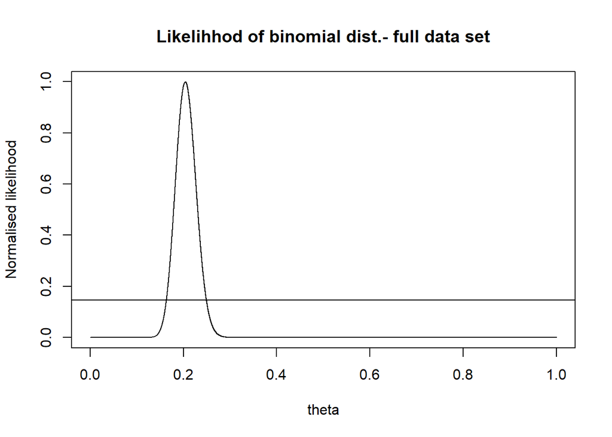

```r
plot(theta, binomial(data, theta)/max(binomial(data, theta)), "l", main = "Likelihhod of binomial dist.- full data set", ylab = "Normalised likelihood")
abline(c,0)
```

```r
a <- theta[binomial(data,theta)/max(binomial(data,theta)) > c]
CI <- c(min(a), max(a))
cat("Maximum Likelihood estimate: ", MLE, "\n")
```

```
## Maximum Likelihood estimate:  0.204142
```

```r
cat("Likelihood Confidence intervals: ", CI)
```

```
## Likelihood Confidence intervals:  0.163498 0.249253
```

## Binomial fit seperately

Data is divided into 2 groups: a control group (without AZT) and a test group (with AZT). A binomial distribution is fitted to each - as in previous question.

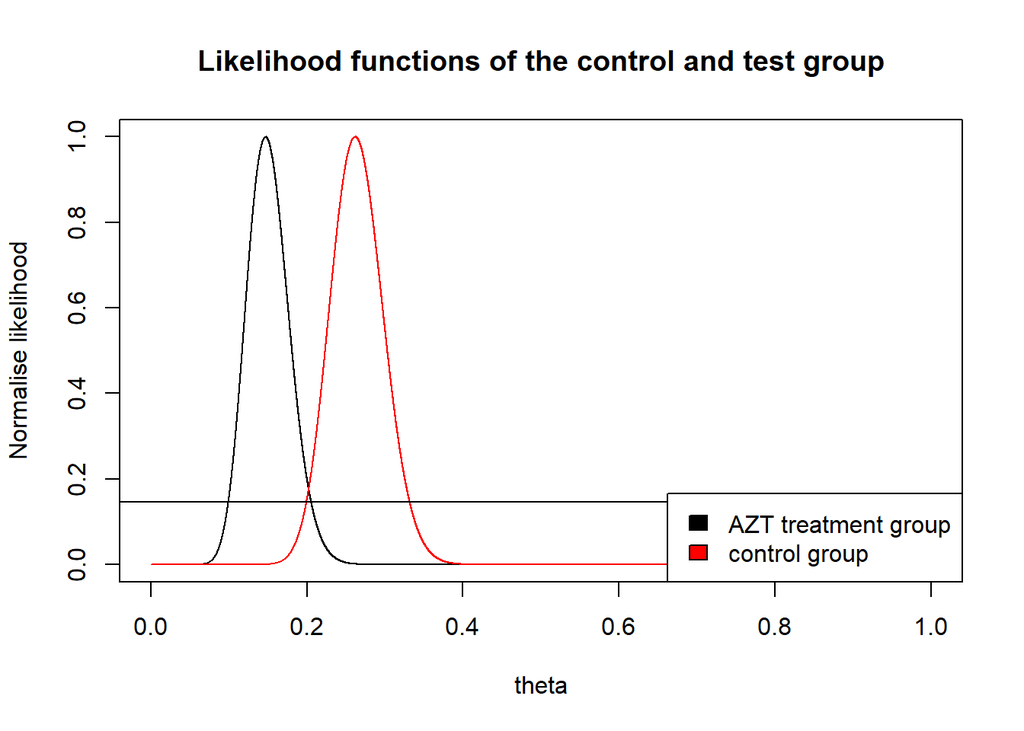

```r
AZT_yes <- as.numeric(log_data[1,2:3])
AZT_no <- as.numeric(log_data[2,2:3])

theta <- seq(0,1,0.00001)

alpha <- 0.05
c <- exp(-1/2*qchisq(1-alpha,1))
plot(theta, binomial(AZT_yes, theta)/max(binomial(AZT_yes, theta)), "l", main = "Likelihood functions of the control and test group", ylab = "Normalise likelihood")
abline(c, 0)
lines(theta, binomial(AZT_no, theta)/max(binomial(AZT_no, theta)), "l", col = "red")
abline(c, 0)
legend("bottomright",legend = c("AZT treatment group", "control group"), fill = c("black", "red"))
```

```r
MLE_yes <- optimize(binomial, c(0,1), data = AZT_yes, maximum = TRUE)$maximum
MLE_no <-  optimize(binomial, c(0,1), data = AZT_no, maximum = TRUE)$maximum

a_yes <- theta[binomial(AZT_yes,theta)/max(binomial(AZT_yes,theta)) > c]
CI_yes <- c(min(a_yes), max(a_yes))

a_no <- theta[binomial(AZT_no,theta)/max(binomial(AZT_no,theta)) > c]
CI_no <- c(min(a_no), max(a_no))

CI_yes
```

```
## [1] 0.09927 0.20540
```

```r
CI_no
```

```
## [1] 0.19936 0.33166
```

## Parameter estimation (logistic)

Estimate the parameters in the model (logistic model) with parameters $\beta_0$ and $\beta_1$

With a logistic model we get the succes probability for the control group $p_0$ and for the test group $p_1$:
$$p_{0}=\frac{e^{\beta_{0}}}{1+e^{\beta_{0}}}, \quad p_{1}=\frac{e^{\beta_{0}+\beta_{1}}}{1+e^{\beta_{0}+\beta_{1}}}$$
The parameter $b_1$ is the parameter describing the difference in succes probabilities ie. if $\beta_1 = 0$ no difference. We can write the likelihood function for the logsitic distribution:
$$L(\beta_0, \beta_1) = \Pi_i p_i^{y_i}(1-p_i)^{1-y_i}$$
with $y_i$ denoting succes in category i. $i=0$ control group, $i=1$ test group. The log likelihood for this is
$$logL(\beta_0, \beta_1) = \sum_i \left[(\beta_0 + \beta_1 \cdot group_i)y_i - log(1 + exp(\beta_0 + \beta_1 \cdot group_i)) \right]$$

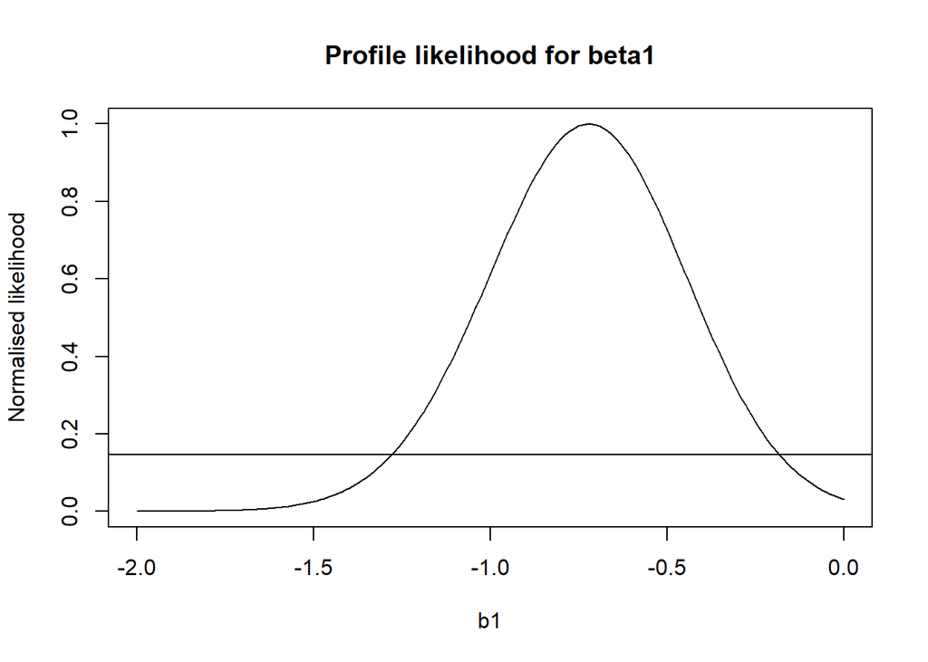

```r
logL_partial <- function(b0, b1, data, AZT = TRUE){
    y = if (AZT) {data[1,2]} else {data[2,2]} %>% as.numeric()
    n = if (AZT) {data[1,3]} else {data[2,3]} %>% as.numeric()
    false = n-y

    y*((b0 + b1 * AZT) * 1 - log(1+exp(b0+b1*AZT))) + false*((b0 + b1 * AZT) * 0 - log(1+exp(b0+b1*AZT)))
}

logL <- function(theta, data){
     - (logL_partial(theta[1], theta[2],data, F) + logL_partial(theta[1],theta[2],data, T))
}


opt <- nlminb(c(0, 0), logL, lower = c(-Inf,-Inf), data = log_data)

p0 <- exp(opt$par[1])/(1+exp(opt$par[1]))
p1 <- exp(opt$par[1] + opt$par[2])/(1+exp(opt$par[1] + opt$par[2]))





logL_b1 <- function(theta, b1, data){
      -(logL_partial(theta[1], b1,data, F) + logL_partial(theta[1],b1,data, T))
}

profile_b1 <- function(b1, data){
  opt <- nlminb(c(0), logL_b1, lower = c(-Inf), data = log_data, b1 = b1)
  # optimize(logL)
  b0 <- opt$par
  -logL_b1(c(b0),b1,data)
}


b1 <- seq(-2,0,0.01)
alpha <- 0.05
c <- exp(-1/2*qchisq(1-alpha,1))
p = c()
for (i in 1:length(b1)){
  p[i] = exp(profile_b1(b1[i], log_data))
}

MLE_b1 <- optimize(profile_b1, c(-5,5), data = log_data, maximum = T)$maximum

plot(b1, p/max(p), 'l', main = "Profile likelihood for beta1", ylab = "Normalised likelihood")
abline(c, 0)
```

```r
# abline(v = MLE_b1)



a_b1 <- b1[p/max(p) > c]
CI_b1 <- c(min(a_b1), max(a_b1))

print(opt$par)
```

```
## [1] -1.036092 -0.721766
```

```r
cat("The maximum likelihood estimates of p0 and p1 are: p0 = ", p0, " p1 = ", p1, "\n")
```

```
## The maximum likelihood estimates of p0 and p1 are: p0 =  0.2619048  p1 =  0.1470588
```

```r
cat("The maximum profile likelihood estimate of b1 is:  ", MLE_b1, "\n")
```

```
## The maximum profile likelihood estimate of b1 is:   -0.7217656
```

```r
cat("With confidence intervals: ", CI_b1, "\n")
```

```
## With confidence intervals:  -1.27 -0.19
```

The 95% confidence interval does not include 0. The difference is significant.

# Analysis of the survival time data

## Summary statistics

The table below shows the proportions of the different groups

```r
act_data <- act_data %>%
  select(time, event, tx)

summary_table <- table(act_data$event, act_data$tx) %>%
  rbind("Total" = colSums(.)) %>%
  cbind("Total" = rowSums(.))
names(attributes(summary_table)$dimnames) <- c("Event", "Treatment")

cat("Summary table:\n")
```

```
## Summary table:
```

```r
summary_table
```

```
##        Treatment
## Event     0   1 Total
##   0     514 541  1055
##   1      63  33    96
##   Total 577 574  1151
```

```r
# summary_table %>% xtable::xtable()
```

## Exponential distribution

The variable ‘event’ describes wheter or not the patient has gotten AIDS (1) or not (0). However, some patients left the study, or the study was terminated before the patients had developed AIDS. Hence for the healthy patients event = 0 the time of event is longer than the time reported. Therefore, we have to work with 2 likelihood functions: $L_{event = 1}(\theta)$ and $L_{event = 0}(\theta)$. $L_{event = 1}(\theta)$ is the usual likelihood function: $L_{event = 1} = \Pi_i f_{\theta} (x_i)$. In the latter case we have to use the survival function $g(x) = 1 - F(x) = 1 - P(X\leq x_i)$ instead of the density. $L_{event = 0}(\theta) = \Pi_i g_{\theta}(x_i) = \Pi_i ( 1 - P(X<x_i))$. The full likelihood is hence $L(\theta) = L_{event = 0}(\theta) L_{event = 1}(\theta)$

### All data

```r
nll <- function(theta, data){
  l1 <- act_data %>%
    filter(event == 1) %>%
    pull(time) %>%
    dexp(rate = theta, log = T)  %>%
    sum()
  l2 <- act_data %>%
    filter(event == 0) %>%
    pull(time) %>%
    (function (x) 1-pexp(x, rate = theta))() %>%
    log() %>%
    sum()
 -(l1+l2)
}

theta <- seq(2e-4, 8e-4, 1e-6)
opt_rate <- optimise(nll, c(1e-10, 1), data = act_data)
```

[output not shown]

```r
c <- exp(-1/2*qchisq(1-alpha,1))
to_be_plotted <- -(sapply(theta, nll, data = act_data) - opt_rate$objective)

# plot(theta, to_be_plotted, "l", main = "Standardized Log likelihood for rate parameter (expontial)", xlab = expression(lambda), ylab = "Log Likelihood")
# abline(h = log(c))
# abline(v = opt_rate$minimum)
# # MLE <- theta[sapply(theta, nll, data =  act_data) == min(sapply(theta, nll, data =  act_data))]
# # abline(v = MLE)
# # abline(v = opt_rate$minimum)
```

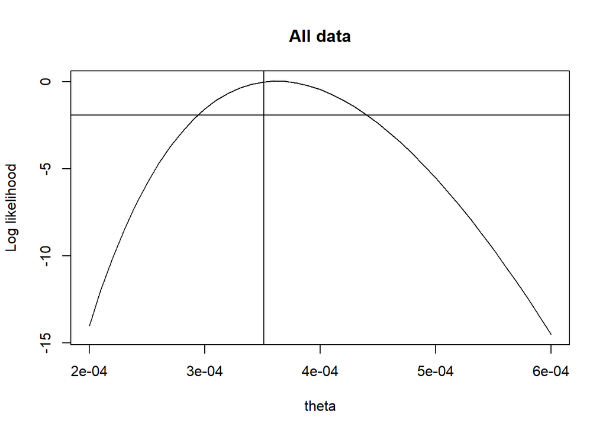

```r
nll <- function(theta, data){
  time <- data$time
  event <- data$event
  sum(event)*log(theta) - theta * sum(time)

}

opt <- optimize(nll, c(1e-10, 1e-1), data = act_data, maximum = T)
theta <- seq(2e-4,6e-4, 1e-5)
plot(theta, sapply(theta, nll, data = act_data) - opt$objective, 'l', ylab = "Log likelihood", main = "All data")
c_l <- -1/2 * qchisq(1-0.05, df = 1)
abline(h = c_l)
abline(v = opt$maximum)
```

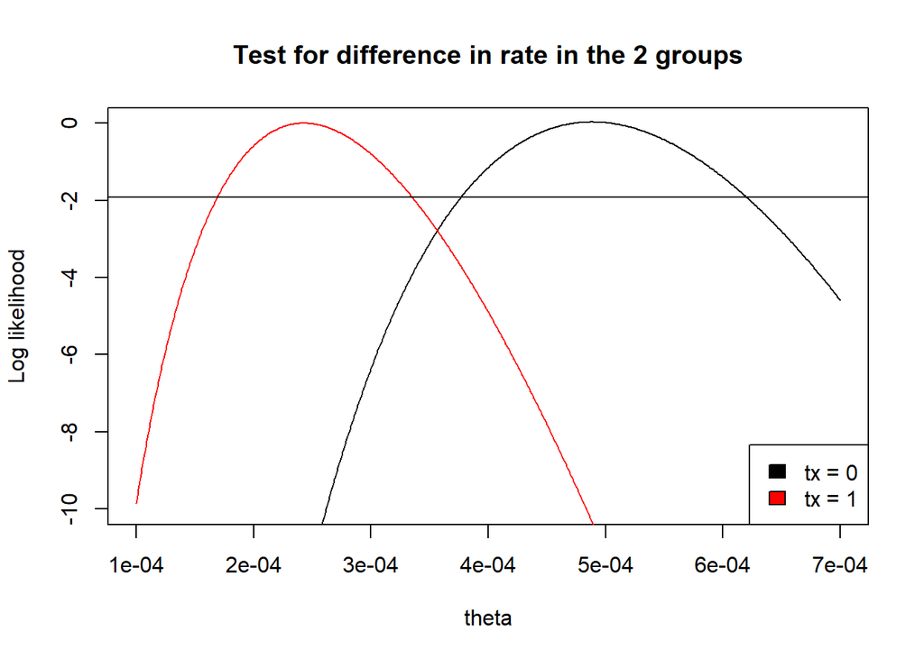

```r
opt0 <- optimize(nll, c(0,1), data = act_data %>% filter(tx == 0), maximum = T)
opt1 <- optimize(nll, c(0,1), data = act_data %>% filter(tx == 1), maximum = T)
theta <- seq(1e-4,7e-4, 1e-6)
plot(theta, nll(theta, act_data %>%  filter(tx == 0)) - opt0$objective, 'l', main = "Test for difference in rate in the 2 groups", ylab = "Log likelihood", ylim = c(-10,0))
lines(theta, nll(theta, act_data %>%  filter(tx == 1)) - opt1$objective, 'l', col = 'red')
legend("bottomright",legend = c("tx = 0", "tx = 1"), fill = c("black", "red"))
abline(h = c_l)
```

```r
CI_tx0_array <- theta[nll(theta, act_data %>% filter(tx == 0)) - opt0$objective > c]
CI_tx0 <- c(min(CI_tx0_array), max(CI_tx0_array))
CI_tx1_array <- theta[nll(theta, act_data %>% filter(tx == 1)) - opt1$objective > c]
CI_tx1 <- c(min(CI_tx1_array), max(CI_tx1_array))
cat("Confidence intervals for tx = 0:", CI_tx0, "\n")
```

```
## Confidence intervals for tx = 0: Inf -Inf
```

```r
cat("confidence intervals for tx = 1:", CI_tx1)
```

```
## confidence intervals for tx = 1: Inf -Inf
```

```r
LR <- exp(opt0$objective - opt1$objective) # Might not be necessary - ignore this
```

```r
## Likelihood function for two parameter model

# nll_help <- function(theta){
#   theta = c(1,1)
#   -sum(log(dexp(act_data %>% filter(event == 1 & tx == 0) %>% pull(time), rate = exp(-theta[1])))) -
#     sum(log(1-pexp(act_data %>% filter(event == 0 & tx == 0) %>% pull(time), rate = exp(-theta[1]))))-
#     sum(log(dexp(act_data %>% filter(event == 1 & tx == 1) %>% pull(time), rate = exp(-theta[1]-theta[2])))) -
#     sum(log(1-pexp(act_data %>% filter(event == 1 & tx == 1) %>% pull(time), rate = exp(-theta[1]-theta[2]))))
# }
# nlminb(c(0,0), nll_help, lower = c(-Inf, -Inf))
# nll_help(c(0,0))


nll <- function(theta, data){
  time <- data$time
  event <- data$event
  sum(event)*log(theta) - theta * sum(time)

}
nll_combined <- function(theta, data){
  rate0 <- exp(-theta[1])
  rate1 <- exp(-(theta[1] + theta[2]))

  -(nll(rate0, data %>% filter(tx == 1)) + nll(rate1, data %>% filter(tx == 0)))

}

# rate.2 <- optim(c(7, 10), nll, hessian = T)
nlminb(c(0,0), nll_combined, lower = c(-Inf, -Inf), data = act_data)
```

```
## $par
## [1]  8.3235425 -0.6991799
##
## $objective
## [1] 851.0115
##
## $convergence
## [1] 0
##
## $iterations
## [1] 17
##
## $evaluations
## function gradient
##       18       43
##
## $message
## [1] "relative convergence (4)"
```

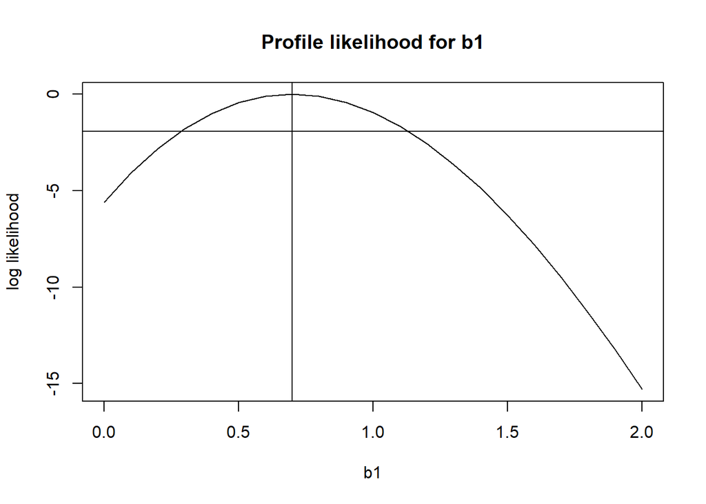

```r
nll_profile <- function(b1, data){
  nll_b0 <- function(b0, b1, data){
  rate0 <- exp(-b0)
  rate1 <- exp(-(b0 + b1))

  -(nll(rate0, data %>% filter(tx == 0)) + nll(rate1, data %>% filter(tx == 1)))
  }
  b0 = nlminb(0, nll_b0, lower = -Inf, data = act_data, b1 = b1)$par
  # b0 = optimise(nll_b0,)

  nll_b0(b0,b1,data)
}
opt_b1 <- nlminb(c(0), nll_profile, lower = c(-Inf), data = act_data)
b1 <- seq(0,2, 0.1)
plot(b1, -sapply(b1, nll_profile, data = act_data)+opt_b1$objective , 'l', main = "Profile likelihood for b1", ylab = "log likelihood")
abline(h= c_l)
abline(v = opt_b1$par)
```

```r
d = act_data$event
t = act_data$tx
y = act_data$time
-(log(sum(t*d)/(sum(y*t))) + 7.624363 )
```

```
## [1] 0.6991719
```

```r
a = sum(d-d*t)
b = sum(d*t)
c = sum(y*(1-t))
d = sum(y*t)

-log((a+b)/(c+d*exp(-0.69)))
```

```
## [1] 7.627525
```

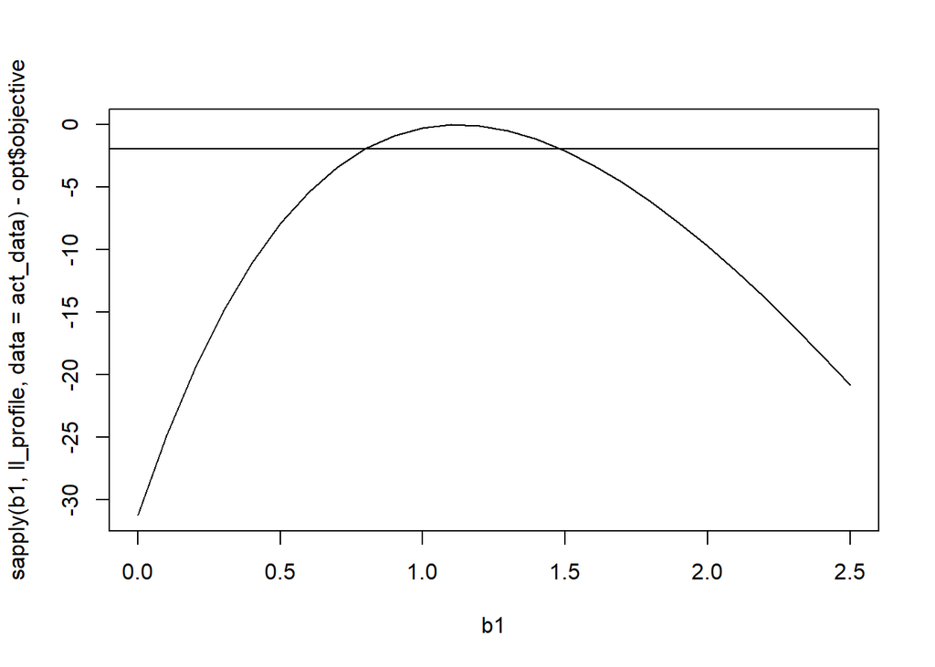

```r
ll_profile <- function(b1, data){
  y = data$time
  d = data$event
  t = data$tx

  a = sum(d-d*t)
  b = sum(d*t)
  c = sum(y*(1-t))
  d2 = sum(y*t)

  MLE_b0 = -log( (a+b)/(c+exp(-b1)) )

  theta0 = exp(-MLE_b0)
  theta1 = exp(-(MLE_b0 + b1))

  a * log(theta0) + b * log(theta1) - c * theta0 - d2 * theta1

}

b1 <- seq(0,2.5,0.1)
opt = optimize(ll_profile, c(-10,10), data = act_data, maximum = T)
plot(b1, sapply(b1, ll_profile, data = act_data) - opt$objective, 'l')
# lines(b1, -sapply(b1, nll_profile, data = act_data)+opt_b1$objective)
abline(h = c_l)
```

```r
y = act_data$time
d = act_data$event
t = act_data$tx

a = sum(d-d*t)
b = sum(d*t)
c = sum(y*(1-t))
d2 = sum(y*t)

MLE_b0 = -log( (a+b)/(c+exp(-0.699172)) )
MLE_B1 = -(log(b/d2)+7.6203 )
```

## Wald confidence interval

The wald confidence interval can be calculated by
$$\hat{\theta} \pm z_{1-\alpha / 2} I^{-1 / 2}(\hat{\theta})$$
where $\hat{\theta}$ is the MLE, z is a quantile in the standard normal distribution and I is the information

```r
opt_bs <- nlminb(c(0,0), nll_combined, lower = c(-Inf, -Inf), data = act_data)
CI_wald <- function(theta_hat, info){theta_hat+c(-1,1)*qnorm(1-0.05/2)*sqrt(1/info)}

hess <- numDeriv::hessian(nll_combined, opt_bs$par, data = act_data)

cat("95% wald confidence interval for b0 is: ", CI_wald(opt_bs$par[1], hess[1,1]))
```

```
## 95% wald confidence interval for b0 is:  8.123504 8.523581
```

```r
cat("\n95% wald confidence interval for b1 is: ", CI_wald(opt_bs$par[2], hess[2,2]))
```

```
##
## 95% wald confidence interval for b1 is:  -0.9461121 -0.4522477
```